# Entrega1

Loading data and Sample selection

Pol Renau Miguel Angel Merino

# Load data

Data is adult.data file located in the current active directory

```r
df<-read.table("adult.data",header=F, sep=",",fill=FALSE,              strip.white=TRUE,na.string="?")
dim(df)
```

```
## [1] 32561    15
```

```r
names(df)
```

```
##  [1] "V1"  "V2"  "V3"  "V4"  "V5"  "V6"  "V7"  "V8"  "V9"  "V10" "V11"
## [12] "V12" "V13" "V14" "V15"
```

```r
names(df)<-c("age", "type.employer", "fnlwgt", "education", "education.num","marital", "occupation",
             "relationship", "race","sex", "capital.gain", "capital.loss",
             "hr.per.week", "country", "y.bin")
summary(df)
```

```
##       age                 type.employer       fnlwgt
##  Min.   :17.00   Private         :22696   Min.   :  12285
##  1st Qu.:28.00   Self-emp-not-inc: 2541   1st Qu.: 117827
##  Median :37.00   Local-gov       : 2093   Median : 178356
##  Mean   :38.58   State-gov       : 1298   Mean   : 189778
##  3rd Qu.:48.00   Self-emp-inc    : 1116   3rd Qu.: 237051
##  Max.   :90.00   (Other)         :  981   Max.   :1484705
##                  NA's            : 1836
##         education     education.num                    marital
##  HS-grad     :10501   Min.   : 1.00   Divorced             : 4443
##  Some-college: 7291   1st Qu.: 9.00   Married-AF-spouse    :   23
##  Bachelors   : 5355   Median :10.00   Married-civ-spouse   :14976
##  Masters     : 1723   Mean   :10.08   Married-spouse-absent:  418
##  Assoc-voc   : 1382   3rd Qu.:12.00   Never-married        :10683
##  11th        : 1175   Max.   :16.00   Separated            : 1025
##  (Other)     : 5134                   Widowed              :  993
##            occupation            relationship                   race
##  Prof-specialty : 4140   Husband       :13193   Amer-Indian-Eskimo:  311
##  Craft-repair   : 4099   Not-in-family : 8305   Asian-Pac-Islander: 1039
##  Exec-managerial: 4066   Other-relative:  981   Black             : 3124
##  Adm-clerical   : 3770   Own-child     : 5068   Other             :  271
##  Sales          : 3650   Unmarried     : 3446   White             :27816
##  (Other)        :10993   Wife          : 1568
##  NA's           : 1843
##      sex         capital.gain    capital.loss     hr.per.week
##  Female:10771   Min.   :    0   Min.   :   0.0   Min.   : 1.00
##  Male  :21790   1st Qu.:    0   1st Qu.:   0.0   1st Qu.:40.00
##                 Median :    0   Median :   0.0   Median :40.00
##                 Mean   : 1078   Mean   :  87.3   Mean   :40.44
##                 3rd Qu.:    0   3rd Qu.:   0.0   3rd Qu.:45.00
##                 Max.   :99999   Max.   :4356.0   Max.   :99.00
##
##           country        y.bin
##  United-States:29170   <=50K:24720
##  Mexico       :  643   >50K : 7841
##  Philippines  :  198
##  Germany      :  137
##  Canada       :  121
##  (Other)      : 1709
##  NA's         :  583
```

## Sample selection

You have to initialize generator seed and select a personal sample of 5000 observations

```r
set.seed(14121997)
sam<-sort(sample(1:nrow(df),5000))


str(df)
```

```
## 'data.frame':    32561 obs. of  15 variables:
##  $ age          : int  39 50 38 53 28 37 49 52 31 42 ...
##  $ type.employer: Factor w/ 8 levels "Federal-gov",..: 7 6 4 4 4 4 4 6 4 4 ...
##  $ fnlwgt       : int  77516 83311 215646 234721 338409 284582 160187 209642 45781 159449 ...
##  $ education    : Factor w/ 16 levels "10th","11th",..: 10 10 12 2 10 13 7 12 13 10 ...
##  $ education.num: int  13 13 9 7 13 14 5 9 14 13 ...
##  $ marital      : Factor w/ 7 levels "Divorced","Married-AF-spouse",..: 5 3 1 3 3 3 4 3 5 3 ...
##  $ occupation   : Factor w/ 14 levels "Adm-clerical",..: 1 4 6 6 10 4 8 4 10 4 ...
##  $ relationship : Factor w/ 6 levels "Husband","Not-in-family",..: 2 1 2 1 6 6 2 1 2 1 ...
##  $ race         : Factor w/ 5 levels "Amer-Indian-Eskimo",..: 5 5 5 3 3 5 3 5 5 5 ...
##  $ sex          : Factor w/ 2 levels "Female","Male": 2 2 2 2 1 1 1 2 1 2 ...
##  $ capital.gain : int  2174 0 0 0 0 0 0 0 14084 5178 ...
##  $ capital.loss : int  0 0 0 0 0 0 0 0 0 0 ...
##  $ hr.per.week  : int  40 13 40 40 40 40 16 45 50 40 ...
##  $ country      : Factor w/ 41 levels "Cambodia","Canada",..: 39 39 39 39 5 39 23 39 39 39 ...
##  $ y.bin        : Factor w/ 2 levels "<=50K",">50K": 1 1 1 1 1 1 1 2 2 2 ...
```

```r
# Select sample
df<-df[sam,]
```

### Save sample binary file

```r
save(list="df",file="mostra.RData")
```

# Income Census Dataset

## Description

*Input variables:*

1. age: continuous.
2. workclass: Private, Self-emp-not-inc, Self-emp-inc, Federal-gov, Local-gov, State-gov, Without-pay, Never-worked.
3. fnlwgt: continuous.
4. education: Bachelors, Some-college, 11th, HS-grad, Prof-school, Assoc-acdm, Assoc-voc, 9th, 7th-8th, 12th, Masters, 1st-4th, 10th, Doctorate, 5th-6th, Preschool.
5. education-num: continuous.
6. marital.status: Married-civ-spouse, Divorced, Never-married, Separated, Widowed, Married-spouse-absent, Married-AF-spouse.
7. occupation: Tech-support, Craft-repair, Other-service, Sales, Exec-managerial, Prof-specialty, Handlers-cleaners, Machine-op-inspct, Adm-clerical, Farming-fishing, Transport-moving, Priv-house-serv, Protective-serv, Armed-Forces.
8. relationship: Wife, Own-child, Husband, Not-in-family, Other-relative, Unmarried.
9. race: White, Asian-Pac-Islander, Amer-Indian-Eskimo, Other, Black.
10. sex: Female, Male.
11. capital.gain: continuous.
12. capital.loss: continuous.
13. hours.per.week: continuous. Numeric target.
14. native.country: United-States, Cambodia, England, Puerto-Rico, Canada, Germany, Outlying-US(Guam-USVI-etc), India, Japan, Greece, South, China, Cuba, Iran, Honduras, Philippines, Italy, Poland, Jamaica, Vietnam, Mexico, Portugal, Ireland, France, Dominican-Republic, Laos, Ecuador, Taiwan, Haiti, Columbia, Hungary, Guatemala, Nicaragua, Scotland, Thailand, Yugoslavia, El-Salvador, Trinadad&Tobago, Peru, Hong, Holand-Netherlands.
15. y.bin: Making more than $50K per year. Binary target.

## Load Packages

Carregarem tots els paquets necessaris per utilitzar al llarg de la pràctica.

```r
options(contrasts=c("contr.treatment","contr.treatment"))

requiredPackages <- c("effects","FactoMineR","car", "factoextra","ggplot2","dplyr","ggmap","ggthemes","knitr")
missingPackages <- requiredPackages[!(requiredPackages %in% installed.packages()[,"Package"])]
if(length(missingPackages)) install.packages(missingPackages)
lapply(requiredPackages, require, character.only = TRUE)
```

```
## Google's Terms of Service: https://cloud.google.com/maps-platform/terms/.
```

[output not shown]

## Load Sample

Carreguem el model previament creat.

```r
# Clear objects
rm(list=ls())
# Clear plots
if(!is.null(dev.list())) dev.off()
```

```r
# Command or Windows-like method
load("mostra.RData")
summary(df)
```

```
##       age                 type.employer      fnlwgt
##  Min.   :17.00   Private         :3476   Min.   :  13769
##  1st Qu.:27.00   Self-emp-not-inc: 400   1st Qu.: 117844
##  Median :36.00   Local-gov       : 320   Median : 178130
##  Mean   :38.18   State-gov       : 214   Mean   : 191672
##  3rd Qu.:47.00   Self-emp-inc    : 160   3rd Qu.: 240818
##  Max.   :90.00   (Other)         : 142   Max.   :1268339
##                  NA's            : 288
##         education    education.num                    marital
##  HS-grad     :1589   Min.   : 1.00   Divorced             : 677
##  Some-college:1161   1st Qu.: 9.00   Married-AF-spouse    :   2
##  Bachelors   : 808   Median :10.00   Married-civ-spouse   :2293
##  Masters     : 260   Mean   :10.05   Married-spouse-absent:  68
##  Assoc-voc   : 210   3rd Qu.:12.00   Never-married        :1669
##  Assoc-acdm  : 166   Max.   :16.00   Separated            : 144
##  (Other)     : 806                   Widowed              : 147
##            occupation           relationship                  race
##  Craft-repair   : 619   Husband       :1986   Amer-Indian-Eskimo:  46
##  Exec-managerial: 608   Not-in-family :1280   Asian-Pac-Islander: 171
##  Prof-specialty : 587   Other-relative: 143   Black             : 453
##  Adm-clerical   : 586   Own-child     : 805   Other             :  41
##  Sales          : 553   Unmarried     : 518   White             :4289
##  (Other)        :1758   Wife          : 268
##  NA's           : 289
##      sex        capital.gain      capital.loss      hr.per.week
##  Female:1685   Min.   :    0.0   Min.   :   0.00   Min.   : 1.00
##  Male  :3315   1st Qu.:    0.0   1st Qu.:   0.00   1st Qu.:40.00
##                Median :    0.0   Median :   0.00   Median :40.00
##                Mean   :  922.1   Mean   :  87.12   Mean   :40.55
##                3rd Qu.:    0.0   3rd Qu.:   0.00   3rd Qu.:45.00
##                Max.   :99999.0   Max.   :3900.00   Max.   :99.00
##
##           country       y.bin
##  United-States:4452   <=50K:3814
##  Mexico       : 109   >50K :1186
##  Philippines  :  28
##  England      :  21
##  Vietnam      :  20
##  (Other)      : 281
##  NA's         :  89
```

#Some useful functions Definim totes les funcions que ens podran ser utils al llarg de la pràctica.

```r
calcQ <- function(x) {
  s.x <- summary(x)
  iqr<-s.x[5]-s.x[2]
  list(souti=s.x[2]-3*iqr, mouti=s.x[2]-1.5*iqr, min=s.x[1], q1=s.x[2], q2=s.x[3],
       q3=s.x[5], max=s.x[6], mouts=s.x[5]+1.5*iqr, souts=s.x[5]+3*iqr ) }

countNA <- function(x) {
  mis_x <- NULL
  for (j in 1:ncol(x)) {mis_x[j] <- sum(is.na(x[,j])) }
  mis_x <- as.data.frame(mis_x)
  rownames(mis_x) <- names(x)
  mis_i <- rep(0,nrow(x))
  for (j in 1:ncol(x)) {mis_i <- mis_i + as.numeric(is.na(x[,j])) }
  list(mis_col=mis_x,mis_ind=mis_i) }
```

# Data Preparation

Preparació de les dades, separem entre aquelles variables que tenen un valor numeric i aquelles que són descriptives

```r
names(df)
```

```
##  [1] "age"           "type.employer" "fnlwgt"        "education"
##  [5] "education.num" "marital"       "occupation"    "relationship"
##  [9] "race"          "sex"           "capital.gain"  "capital.loss"
## [13] "hr.per.week"   "country"       "y.bin"
```

```r
vars_con<-names(df)[c(1,3,5,11:13)];vars_con
```

```
## [1] "age"           "fnlwgt"        "education.num" "capital.gain"
## [5] "capital.loss"  "hr.per.week"
```

```r
vars_dis<-names(df)[c(2,4,6:10,14:15)];vars_dis
```

```
## [1] "type.employer" "education"     "marital"       "occupation"
## [5] "relationship"  "race"          "sex"           "country"
## [9] "y.bin"
```

```r
summary(df[,vars_con]) # Example of descriptive for numeric variables
```

```
##       age            fnlwgt        education.num    capital.gain
##  Min.   :17.00   Min.   :  13769   Min.   : 1.00   Min.   :    0.0
##  1st Qu.:27.00   1st Qu.: 117844   1st Qu.: 9.00   1st Qu.:    0.0
##  Median :36.00   Median : 178130   Median :10.00   Median :    0.0
##  Mean   :38.18   Mean   : 191672   Mean   :10.05   Mean   :  922.1
##  3rd Qu.:47.00   3rd Qu.: 240818   3rd Qu.:12.00   3rd Qu.:    0.0
##  Max.   :90.00   Max.   :1268339   Max.   :16.00   Max.   :99999.0
##   capital.loss      hr.per.week
##  Min.   :   0.00   Min.   : 1.00
##  1st Qu.:   0.00   1st Qu.:40.00
##  Median :   0.00   Median :40.00
##  Mean   :  87.12   Mean   :40.55
##  3rd Qu.:   0.00   3rd Qu.:45.00
##  Max.   :3900.00   Max.   :99.00
```

```r
summary(df[,vars_dis])
```

```
##           type.employer         education                     marital
##  Private         :3476   HS-grad     :1589   Divorced             : 677
##  Self-emp-not-inc: 400   Some-college:1161   Married-AF-spouse    :   2
##  Local-gov       : 320   Bachelors   : 808   Married-civ-spouse   :2293
##  State-gov       : 214   Masters     : 260   Married-spouse-absent:  68
##  Self-emp-inc    : 160   Assoc-voc   : 210   Never-married        :1669
##  (Other)         : 142   Assoc-acdm  : 166   Separated            : 144
##  NA's            : 288   (Other)     : 806   Widowed              : 147
##            occupation           relationship                  race
##  Craft-repair   : 619   Husband       :1986   Amer-Indian-Eskimo:  46
##  Exec-managerial: 608   Not-in-family :1280   Asian-Pac-Islander: 171
##  Prof-specialty : 587   Other-relative: 143   Black             : 453
##  Adm-clerical   : 586   Own-child     : 805   Other             :  41
##  Sales          : 553   Unmarried     : 518   White             :4289
##  (Other)        :1758   Wife          : 268
##  NA's           : 289
##      sex                country       y.bin
##  Female:1685   United-States:4452   <=50K:3814
##  Male  :3315   Mexico       : 109   >50K :1186
##                Philippines  :  28
##                England      :  21
##                Vietnam      :  20
##                (Other)      : 281
##                NA's         :  89
```

# Factor preparation

## type.employer

```r
levels(df$type.employer)
```

```
## [1] "Federal-gov"      "Local-gov"        "Never-worked"
## [4] "Private"          "Self-emp-inc"     "Self-emp-not-inc"
## [7] "State-gov"        "Without-pay"
```

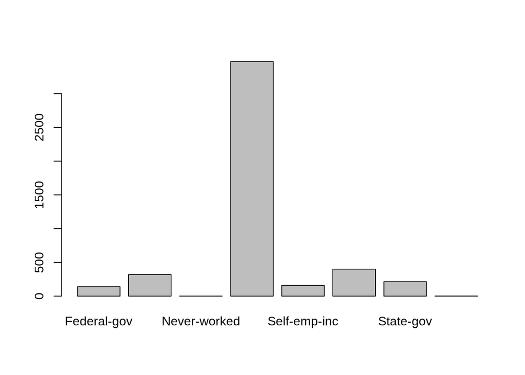

```r
# Graphic tool for Univ EDA and factors
barplot(table(df$type.employer))
```

```r
table(df$type.employer)
```

```
##
##      Federal-gov        Local-gov     Never-worked          Private
##              139              320                1             3476
##     Self-emp-inc Self-emp-not-inc        State-gov      Without-pay
##              160              400              214                2
```

```r
# Conceptual decission : federal, local and state gov are grouped together - Private alone , Self-emp and the rest together

# Use target means

tapply(df$hr.per.week,df$type.employer,mean)
```

```
##      Federal-gov        Local-gov     Never-worked          Private
##         40.67626         40.85938          4.00000         40.38003
##     Self-emp-inc Self-emp-not-inc        State-gov      Without-pay
##         47.97500         45.73750         39.46262         33.00000
```

```r
df$f.type<-1
ll<-which(df$type.employer == "Private");length(ll)
```

```
## [1] 3476
```

```r
df$f.type[ll]<-2
df[ll,"f.type"]<-2 # f.type already available
ll<-which(df$type.employer == "Self-emp-inc");length(ll)
```

```
## [1] 160
```

```r
df$f.type[ll]<-3
ll<-which(df$type.employer %in% c("Self-emp-not-inc","Never-worked","Without-pay"));length(ll)
```

```
## [1] 403
```

```r
df$f.type[ll]<-4

# Define f.type as a factor and use 'nice' level names

paste0("f.typ-",c("Civil","Private","SelfEm","Other"))
```

```
## [1] "f.typ-Civil"   "f.typ-Private" "f.typ-SelfEm"  "f.typ-Other"
```

```r
df$f.type<-factor(df$f.type,levels=1:4,labels=paste0("f.typ-",c("Civil","Private","SelfEm","Other")))

summary(df$f.type)
```

```
##   f.typ-Civil f.typ-Private  f.typ-SelfEm   f.typ-Other
##           961          3476           160           403
```

## Sex - Change label names

```r
levels(df$sex)<-paste0("Sex-",levels(df$sex))
summary(df$sex)
```

```
## Sex-Female   Sex-Male
##       1685       3315
```

```r
# Univariant EDA
100*table(df$sex)/nrow(df)
```

```
##
## Sex-Female   Sex-Male
##       33.7       66.3
```

```r
prop.table(table(df$sex))
```

```
##
## Sex-Female   Sex-Male
##      0.337      0.663
```

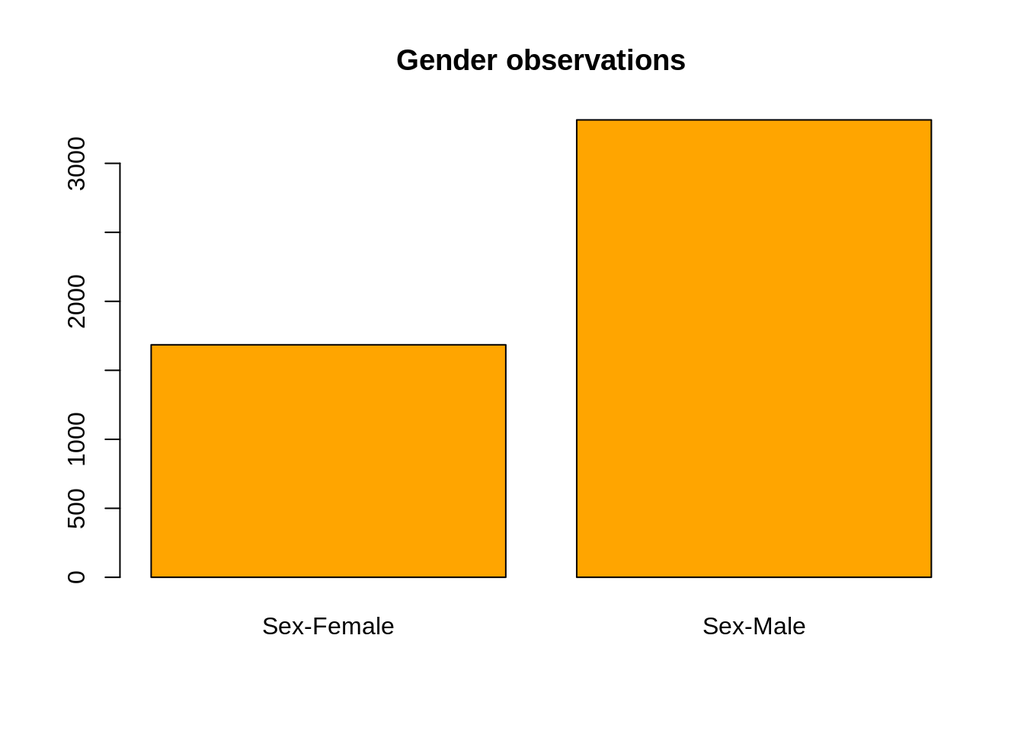

```r
# Graphic tools
barplot(table(df$sex),main="Gender observations",col="orange")
```

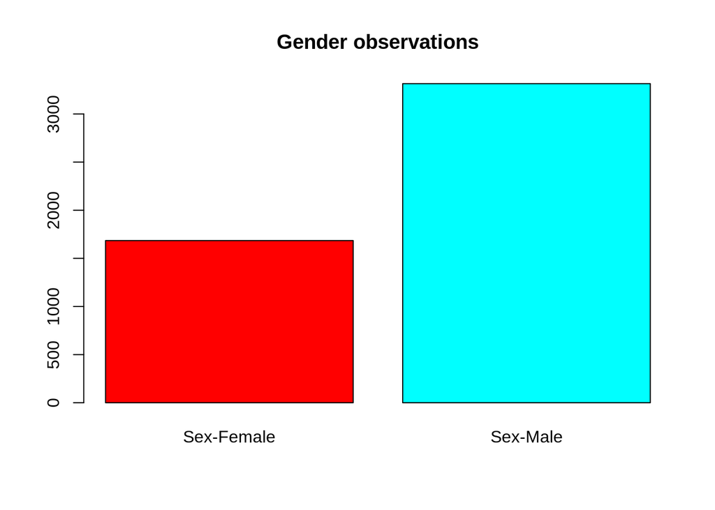

```r
barplot(table(df$sex),main="Gender observations",col=rainbow(2))
```

## Numeric variables - Discretization

### Age

```r
summary(df$age)
```

```
##    Min. 1st Qu.  Median    Mean 3rd Qu.    Max.
##   17.00   27.00   36.00   38.18   47.00   90.00
```

```r
# Try 4 categories first
quantile(df$age)
```

```
##   0%  25%  50%  75% 100%
##   17   27   36   47   90
```

```r
cut(df$age,quantile(df$age))
```

[output not shown]

[output cut: 611 more lines]

```r
df$f.age<-factor(cut(df$age,quantile(df$age),include.lowest = T))
summary(df$f.age)
```

```
## [17,27] (27,36] (36,47] (47,90]
##    1289    1223    1266    1222
```

```r
# Reasonable according to target?
tapply(df$age,df$f.age,median) # OK
```

```
## [17,27] (27,36] (36,47] (47,90]
##      23      32      42      55
```

```r
# Alternative breaks defined at 30,40,50
df$f.age<-factor(cut(df$age,c(17,29,39,49,90),include.lowest = T))
summary(df$f.age)
```

```
## [17,29] (29,39] (39,49] (49,90]
##    1556    1323    1075    1046
```

```r
levels(df$f.age)<-paste0("f.age-",levels(df$f.age))
```

## Univariant EDA - Numeric variables

### age

```r
# Numeric indicators - statistics
summary(df$age)
```

```
##    Min. 1st Qu.  Median    Mean 3rd Qu.    Max.
##   17.00   27.00   36.00   38.18   47.00   90.00
```

```r
quantile(df$age,seq(0,1,by=0.1)) # Decils of df$age
```

```
##   0%  10%  20%  30%  40%  50%  60%  70%  80%  90% 100%
## 17.0 21.0 25.0 29.0 33.0 36.0 40.4 45.0 50.0 58.0 90.0
```

```r
# Desviació tipus
sd(df$age)
```

```
## [1] 13.63794
```

```r
# Variance
var(df$age)
```

```
## [1] 185.9935
```

```r
# Coefficient of variation
sd(df$age)/mean(df$age)
```

```
## [1] 0.3571788
```

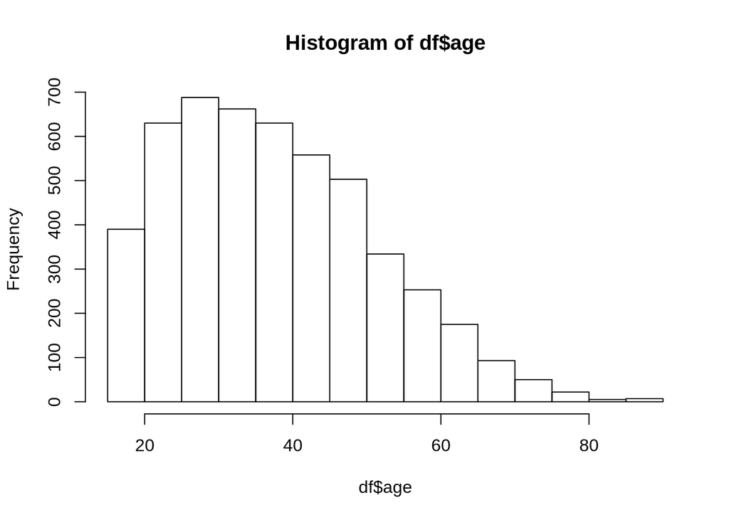

```r
# Graphical tools
hist(df$age)
```

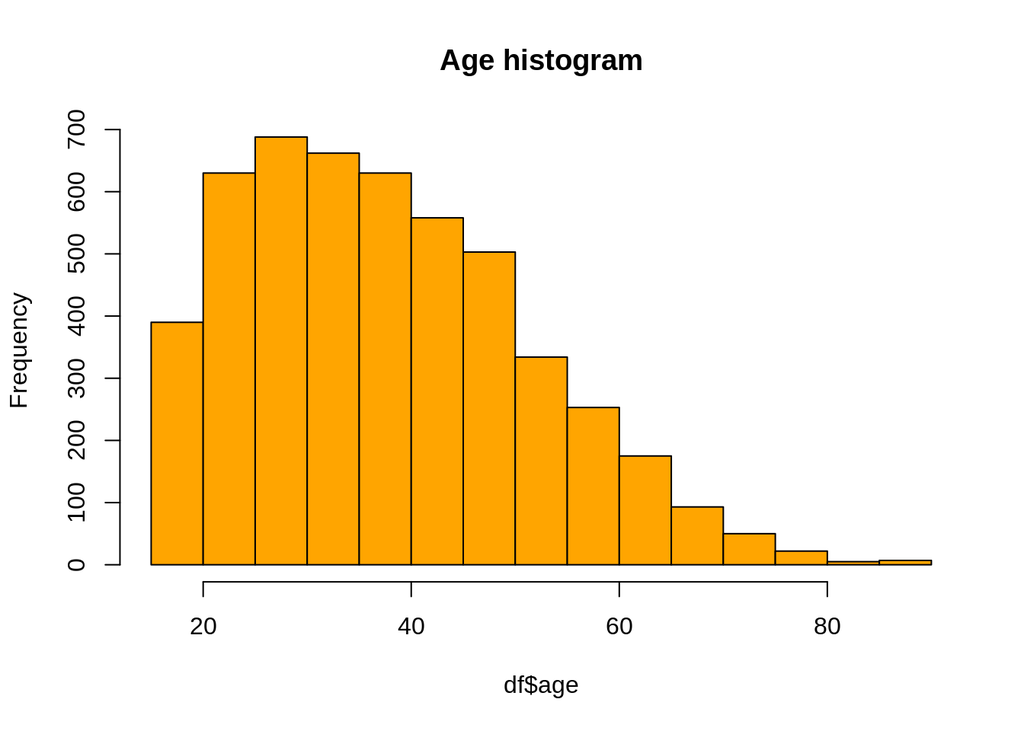

```r
hist(df$age,main="Age histogram",col="orange")
```

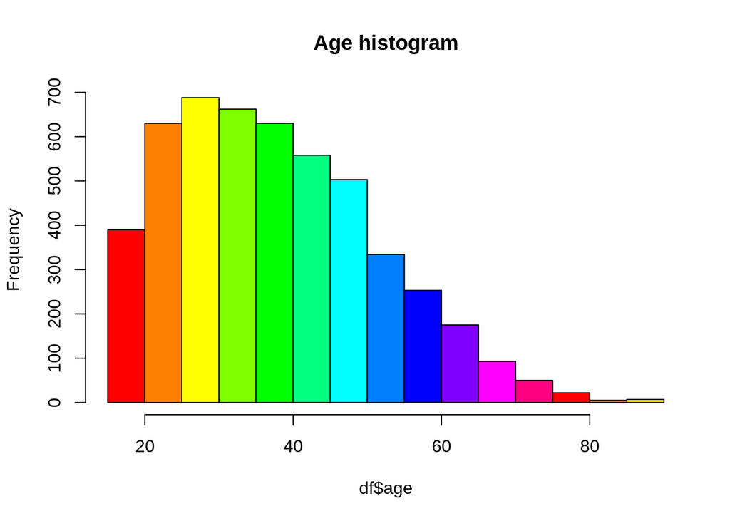

```r
hist(df$age,main="Age histogram",col=rainbow(12))
```

```r
mm<-mean(df$age);dd<-sd(df$age);mm;dd
```

```
## [1] 38.1824
```

```
## [1] 13.63794
```

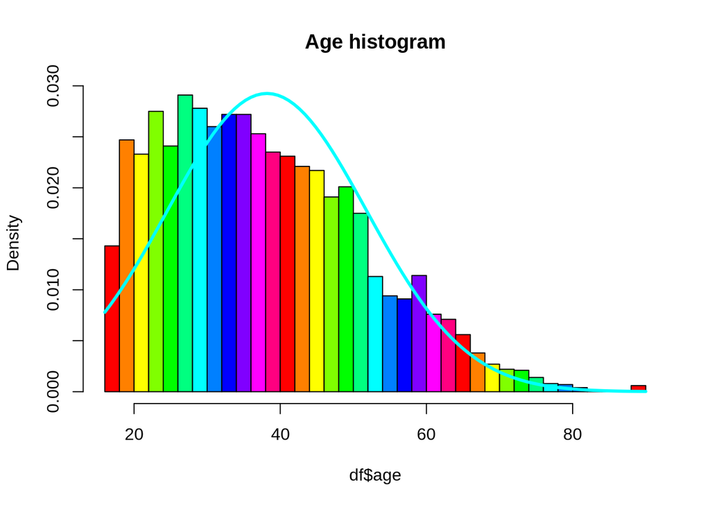

```r
hist(df$age,freq=F,30,main="Age histogram",col=rainbow(12))
curve(dnorm(x,mean=mm,sd=dd),col="cyan",lwd=3,add=T)
```

```r
# Outlier detection
boxplot(df$age,main="Boxplot age")
summary(df$age)
```

```
##    Min. 1st Qu.  Median    Mean 3rd Qu.    Max.
##   17.00   27.00   36.00   38.18   47.00   90.00
```

```r
outsev<-48+3*(48-27)
outsua<-48+1.5*(48-27);outsev;outsua
```

```
## [1] 111
```

```
## [1] 79.5
```

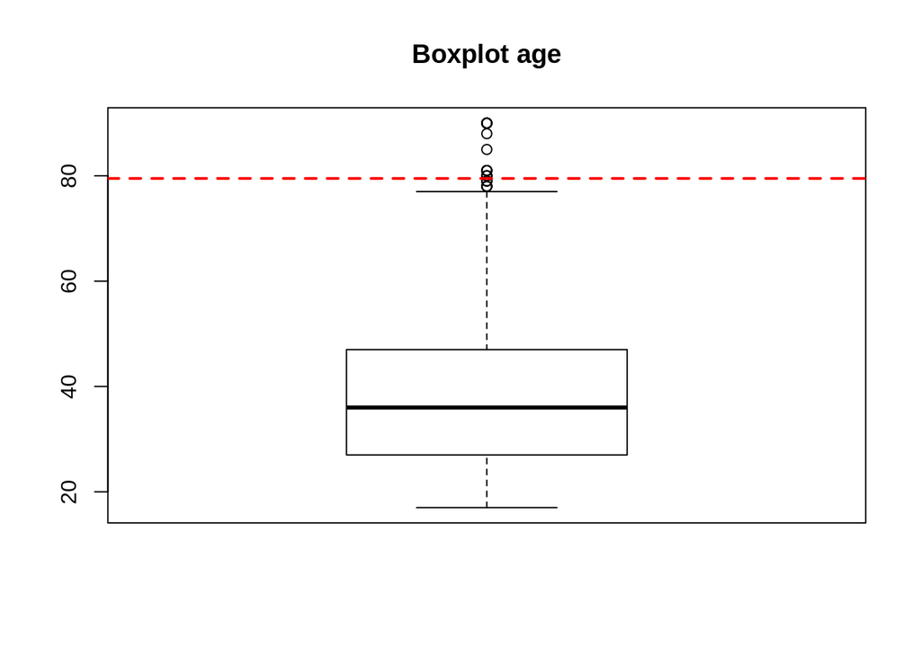

```r
abline(h=outsua,col="red",lwd=2,lty=2)
```

# Missing data: initial situation

```r
miss<-countNA(df)
attributes(miss)
```

```
## $names
## [1] "mis_col" "mis_ind"
```

```r
miss$mis_col  # Number of missing values for each variable
```

```
##               mis_x
## age               0
## type.employer   288
## fnlwgt            0
## education         0
## education.num     0
## marital           0
## occupation      289
## relationship      0
## race              0
## sex               0
## capital.gain      0
## capital.loss      0
## hr.per.week       0
## country          89
## y.bin             0
## f.type            0
## f.age             0
```

```r
summary(df)
```

```
##       age                 type.employer      fnlwgt
##  Min.   :17.00   Private         :3476   Min.   :  13769
##  1st Qu.:27.00   Self-emp-not-inc: 400   1st Qu.: 117844
##  Median :36.00   Local-gov       : 320   Median : 178130
##  Mean   :38.18   State-gov       : 214   Mean   : 191672
##  3rd Qu.:47.00   Self-emp-inc    : 160   3rd Qu.: 240818
##  Max.   :90.00   (Other)         : 142   Max.   :1268339
##                  NA's            : 288
##         education    education.num                    marital
##  HS-grad     :1589   Min.   : 1.00   Divorced             : 677
##  Some-college:1161   1st Qu.: 9.00   Married-AF-spouse    :   2
##  Bachelors   : 808   Median :10.00   Married-civ-spouse   :2293
##  Masters     : 260   Mean   :10.05   Married-spouse-absent:  68
##  Assoc-voc   : 210   3rd Qu.:12.00   Never-married        :1669
##  Assoc-acdm  : 166   Max.   :16.00   Separated            : 144
##  (Other)     : 806                   Widowed              : 147
##            occupation           relationship                  race
##  Craft-repair   : 619   Husband       :1986   Amer-Indian-Eskimo:  46
##  Exec-managerial: 608   Not-in-family :1280   Asian-Pac-Islander: 171
##  Prof-specialty : 587   Other-relative: 143   Black             : 453
##  Adm-clerical   : 586   Own-child     : 805   Other             :  41
##  Sales          : 553   Unmarried     : 518   White             :4289
##  (Other)        :1758   Wife          : 268
##  NA's           : 289
##          sex        capital.gain      capital.loss      hr.per.week
##  Sex-Female:1685   Min.   :    0.0   Min.   :   0.00   Min.   : 1.00
##  Sex-Male  :3315   1st Qu.:    0.0   1st Qu.:   0.00   1st Qu.:40.00
##                    Median :    0.0   Median :   0.00   Median :40.00
##                    Mean   :  922.1   Mean   :  87.12   Mean   :40.55
##                    3rd Qu.:    0.0   3rd Qu.:   0.00   3rd Qu.:45.00
##                    Max.   :99999.0   Max.   :3900.00   Max.   :99.00
##
##           country       y.bin                f.type
##  United-States:4452   <=50K:3814   f.typ-Civil  : 961
##  Mexico       : 109   >50K :1186   f.typ-Private:3476
##  Philippines  :  28                f.typ-SelfEm : 160
##  England      :  21                f.typ-Other  : 403
##  Vietnam      :  20
##  (Other)      : 281
##  NA's         :  89
##            f.age
##  f.age-[17,29]:1556
##  f.age-(29,39]:1323
##  f.age-(39,49]:1075
##  f.age-(49,90]:1046
##
##
##
```

```r
miss$mis_ind # Number of missing values in variables for each observation
```

[output not shown]

[output cut: 133 more lines]

```r
summary(miss$mis_ind)
```

```
##    Min. 1st Qu.  Median    Mean 3rd Qu.    Max.
##  0.0000  0.0000  0.0000  0.1332  0.0000  3.0000
```

```r
quantile(miss$mis_ind,seq(0,1,0.1))
```

```
##   0%  10%  20%  30%  40%  50%  60%  70%  80%  90% 100%
##    0    0    0    0    0    0    0    0    0    0    3
```

# Outliers and Errors: initial situation

```r
iout<-rep(0,nrow(df))
jout<-rep(0,length(vars_con))

ierr<-rep(0,nrow(df))
jerr<-rep(0,ncol(df))
```

## hr.per.week (numeric target)

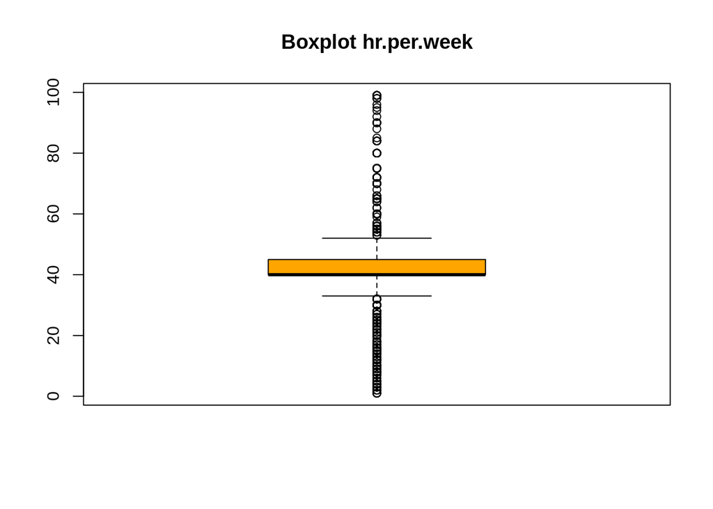

```r
summ<-summary(df$hr.per.week)
boxplot(df$hr.per.week,main="Boxplot hr.per.week",col="orange")
```

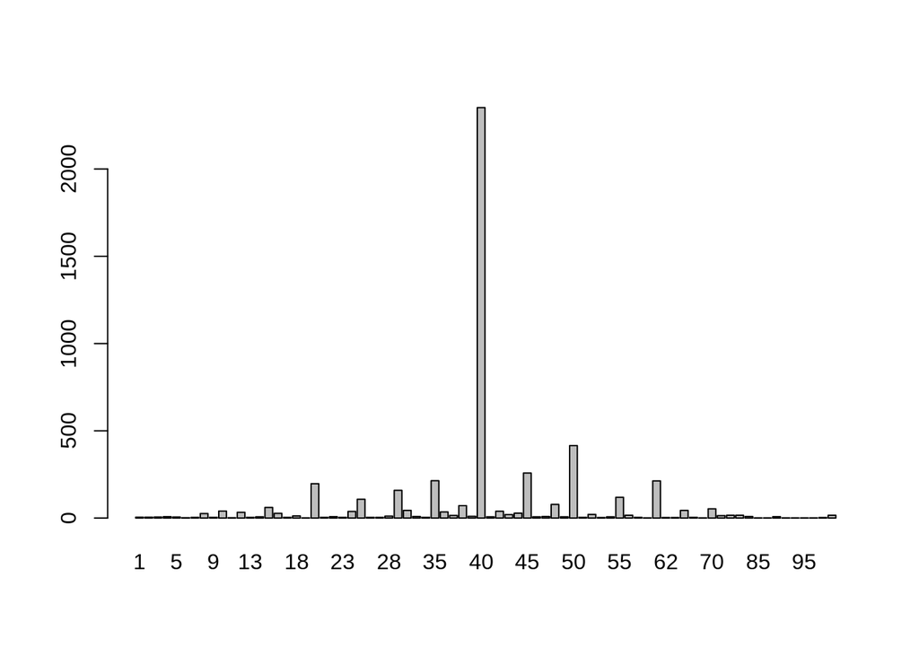

```r
barplot(table(df$hr.per.week))
```

```r
iqr<-summ[5]-summ[2];iqr
```

```
## 3rd Qu.
##       5
```

```r
souts<-summ[5]+3*iqr  # upper threshold
souti<-summ[2]-3*iqr# lower threshold
souti;souts
```

```
## 1st Qu.
##      25
```

```
## 3rd Qu.
##      60
```

```r
ll<-which((df$hr.per.week<souti)|(df$hr.per.week>souts));length(ll)
```

```
## [1] 704
```

```r
ll<-which((df$hr.per.week<5)|(df$hr.per.week>80));length(ll)
```

```
## [1] 66
```

```r
### Special treatment: target - Errors or Severe outliers - Remove

dff<-df[-ll,]

### End Special treatment: target - Errors or Severe outliers - Remove

# Update iout,jout,ierr,jerr
jerr[13]<-jerr[13]+length(ll)
ierr[ll]<-ierr[ll]+1

calcQ(df$hr.per.week)
```

```
## $souti
## 1st Qu.
##      25
##
## $mouti
## 1st Qu.
##    32.5
##
## $min
## Min.
##    1
##
## $q1
## 1st Qu.
##      40
##
## $q2
## Median
##     40
##
## $q3
## 3rd Qu.
##      45
##
## $max
## Max.
##   99
##
## $mouts
## 3rd Qu.
##    52.5
##
## $souts
## 3rd Qu.
##      60
```

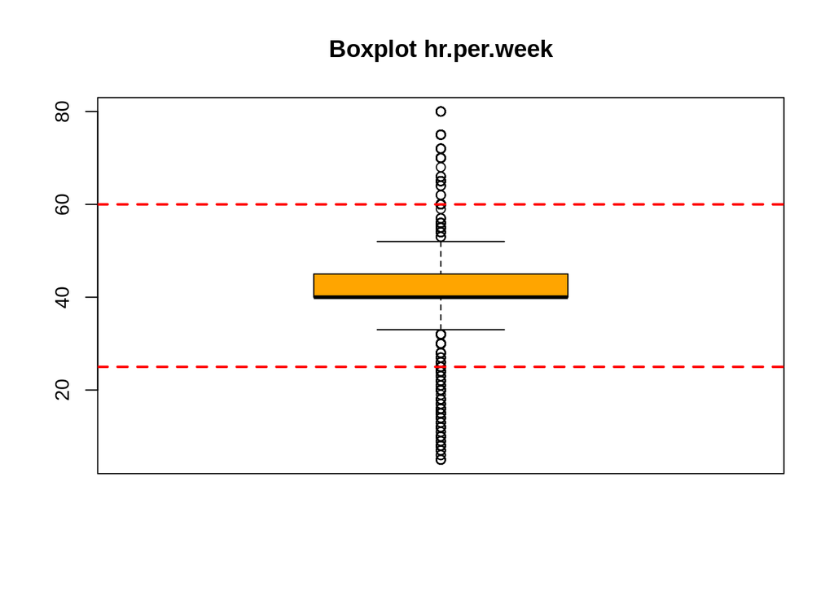

```r
boxplot(dff$hr.per.week,main="Boxplot hr.per.week",col="orange")
abline(h=calcQ(dff$hr.per.week)$souti,lwd=2,col="red",lty=2)
abline(h=calcQ(dff$hr.per.week)$souts,lwd=2,col="red",lty=2)
```

Fer per totes les variables numèriques (outliers i errors) i factors (errors, si cal identifiqueu les categories missing).

# Imputation

Set some reasonable value to missing data. Missing can be an original missing or an error/outlier set to missing